# Optimizing_Black_Friday_Sales_Prediction

Business Problem

We are trying to predict how much an individual customer will spend during a black Friday sale. This type of modeling is particularly useful for pricing campaigns and creating deals for specific customers.

Import Libraries

```python
# Importing necessary libraries
import numpy as np
import pandas as pd
import warnings

# Suppress all warnings
warnings.filterwarnings("ignore")
```

```python
# Importing necessary modules from the scikit-learn library for machine learning
from sklearn.model_selection import cross_val_score, train_test_split
from sklearn.impute import SimpleImputer
from sklearn.compose import ColumnTransformer
from sklearn.model_selection import GridSearchCV
```

SimpleImputer class, which is used for imputing missing values in a dataset. This is particularly useful when dealing with datasets that have missing values in some of their features.

ColumnTransformer class is used for applying transformers to specific columns of a dataset. This is helpful when we want to apply different preprocessing steps to different subsets of features.

```python
from google.colab import drive
drive.mount('/content/drive')
```

```python
file_path = '/content/drive/MyDrive/train.csv'
black_friday_sales = pd.read_csv(file_path)
```

```python
black_friday_sales.head()
```

|  | User_ID | Product_ID | Gender | Age | Occupation | City_Category | Stay_In_Current_City_Years | Marital_Status | Product_Category_1 | Product_Category_2 | Product_Category_3 | Purchase |
| --- | --- | --- | --- | --- | --- | --- | --- | --- | --- | --- | --- | --- |
| 0 | 1000001 | P00069042 | F | 0-17 | 10 | A | 2 | 0 | 3 | NaN | NaN | 8370 |
| 1 | 1000001 | P00248942 | F | 0-17 | 10 | A | 2 | 0 | 1 | 6.0 | 14.0 | 15200 |
| 2 | 1000001 | P00087842 | F | 0-17 | 10 | A | 2 | 0 | 12 | NaN | NaN | 1422 |
| 3 | 1000001 | P00085442 | F | 0-17 | 10 | A | 2 | 0 | 12 | 14.0 | NaN | 1057 |
| 4 | 1000002 | P00285442 | M | 55+ | 16 | C | 4+ | 0 | 8 | NaN | NaN | 7969 |

```python
# Counting the occurrences of each unique value in the 'Age' column
black_friday_sales.Age.value_counts()
```

```
26-35    219587
36-45    110013
18-25     99660
46-50     45701
51-55     38501
55+       21504
0-17      15102
Name: Age, dtype: int64
```

The output of above code provides insights into the age distribution of customers participating in Black Friday sales, showing the count of individuals in different age categories.

```python
# Printing the data types of each column
column_data_types = black_friday_sales.dtypes
print(column_data_types)
```

```
User_ID                         int64
Product_ID                     object
Gender                         object
Age                            object
Occupation                      int64
City_Category                  object
Stay_In_Current_City_Years     object
Marital_Status                  int64
Product_Category_1              int64
Product_Category_2            float64
Product_Category_3            float64
Purchase                        int64
dtype: object
```

Data Preprocessing

In this section, we will fix a few of the columns which are mentioned below:

Occupation: we will convert this to categorical

Maritial_status: we will convert this to categorical

product_categories: cwe will convert this to categorical

Stay_In_Current_City_Years: we will convert this to numerical

Age: We will format the age.

```python
#change to categorical from numeric
black_friday_sales.Occupation = pd.Categorical(black_friday_sales['Occupation'])
black_friday_sales.Marital_Status = pd.Categorical(black_friday_sales['Marital_Status'])
black_friday_sales.Product_Category_1 = pd.Categorical(black_friday_sales['Product_Category_1'])
black_friday_sales.Product_Category_2 = pd.Categorical(black_friday_sales['Product_Category_2'])
black_friday_sales.Product_Category_3 = pd.Categorical(black_friday_sales['Product_Category_3'])

#change to numeric
black_friday_sales.Stay_In_Current_City_Years = black_friday_sales.Stay_In_Current_City_Years.str.replace('+','').astype(int)


# Defining a function to replace 'Age' values with random values within specified ranges
def random_age_replace(black_friday_sales_in,old_col,new_col):
    np.random.seed(1)
    black_friday_sales_out = black_friday_sales_in.copy()
    black_friday_sales_out[new_col] = black_friday_sales_out[old_col]
    vals = black_friday_sales_out[old_col].value_counts()
    for i in vals.index:
        if len(i.split('-')) > 1:
            low = int(i.split('-')[0])
            high = int(i.split('-')[1])
            size = black_friday_sales_out[black_friday_sales_out[new_col] == i].shape[0]
            black_friday_sales_out.loc[black_friday_sales_out[old_col] == i, new_col] = np.random.randint(low,high,size)
        else:
            size = black_friday_sales_out[black_friday_sales_out[new_col] == i].shape[0]
            black_friday_sales_out.loc[black_friday_sales_out[old_col] == i, new_col] = np.random.randint(55,90,size)
    return black_friday_sales_out

# Applying the function to replace 'Age' values with 'New_Age'
black_friday_sales = random_age_replace(black_friday_sales,'Age','New_Age')
black_friday_sales.New_Age = black_friday_sales.New_Age.astype(int)
```

The 'Stay_In_Current_City_Years' column is converted to numeric by removing the '+' and converting to integers.

The 'Age' column is replaced with a new column ('New_Age') containing random values within specified ranges. The random replacement is done based on the distribution of existing values in the original 'Age' column.

Exploratory Data Analysis

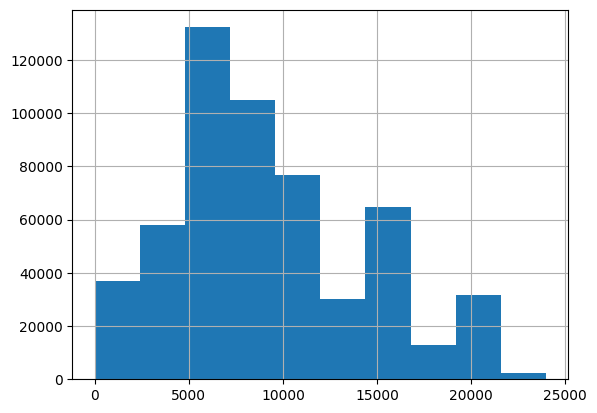

```python
black_friday_sales.Purchase.hist()
```

Insights:

It can be said that maximum people are shopping between the range of 5000-10000$.

The number of people who are spending between 20K-25K are least in numbers which is normal.

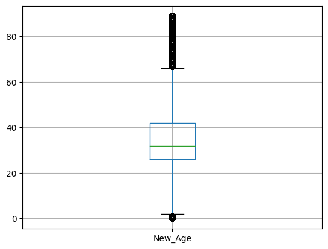

```python
black_friday_sales.boxplot(column=['New_Age'])
```

```python
# Calculating the percentage of missing values for each column
black_friday_sales.isnull().sum()/black_friday_sales.shape[0]
```

```
User_ID                       0.000000
Product_ID                    0.000000
Gender                        0.000000
Age                           0.000000
Occupation                    0.000000
City_Category                 0.000000
Stay_In_Current_City_Years    0.000000
Marital_Status                0.000000
Product_Category_1            0.000000
Product_Category_2            0.315666
Product_Category_3            0.696727
Purchase                      0.000000
New_Age                       0.000000
dtype: float64
```

Columns 'Product_Category_2' and 'Product_Category_3' have missing values.

About 31.57% of 'Product_Category_2' values are missing.

About 69.67% of 'Product_Category_3' values are missing.

Data Preprocessing

(1) Data imputation

(2) Imputing & Outlier Removal

(3) Imputing and Scaling

(4) Imputing, Scaling, and Outlier Removal

```python
black_friday_sales.columns
```

```
Index(['User_ID', 'Product_ID', 'Gender', 'Age', 'Occupation', 'City_Category',
       'Stay_In_Current_City_Years', 'Marital_Status', 'Product_Category_1',
       'Product_Category_2', 'Product_Category_3', 'Purchase', 'New_Age'],
      dtype='object')
```

'User_ID': Represents unique identifiers for users. No specific insights can be gained without additional context.

'Product_ID': Represents unique identifiers for products. No specific insights can be gained without additional context.

'Gender': Indicates the gender of the customers. Insight can be gained into the gender distribution of Black Friday shoppers.

'Age': Categorical representation of age groups. Insights into the age distribution of customers during Black Friday.

'Occupation': Numeric representation of customer occupations. Insights into the diversity of occupations among Black Friday shoppers.

'City_Category': Represents the category of the city where the customer resides. Provides information about the geographic distribution of customers.

'Stay_In_Current_City_Years': Indicates the number of years the customer has stayed in the current city. Insights into customer mobility or stability.

'Marital_Status': Binary representation of marital status (0 - Single, 1 - Married). Insights into the marital status distribution of customers.

'Product_Category_1', 'Product_Category_2', 'Product_Category_3': Numeric representation of product categories. Insights into the popularity or diversity of product categories.

'Purchase': Represents the amount spent by customers. Insights into the overall spending distribution during Black Friday.

'New_Age': Represents randomly replaced age values. Insights into the distribution after the randomization process.

```python
# Fill imputed categories with value indicating it is nan - 21
from sklearn.impute import SimpleImputer
from sklearn.compose import ColumnTransformer

cols_to_impute = ['Product_Category_1',
                  'Product_Category_2',
                  'Product_Category_3']

cols_to_category = ['Gender',
                    'Occupation',
                    'City_Category',
                    'Marital_Status',
                    'Product_Category_1',
                    'Product_Category_2',
                    'Product_Category_3']

cols_to_scale = ['New_Age',
                 'Stay_In_Current_City_Years']
```

The overall goal is to handle missing values in a controlled manner, filling them with a specific constant value (21 in this case) and transforming selected columns to categorical types.

Impute NaN's

```python
categorical_imputer = SimpleImputer(strategy='constant', fill_value=21)

impute_preprocessor = ColumnTransformer(
    transformers=[
        ('cat_impute', categorical_imputer, cols_to_impute),
    ],remainder = 'passthrough',
    verbose_feature_names_out= False).set_output(transform='pandas')
```

The code sets up a categorical imputer using SimpleImputer to fill missing values in specified categorical columns with a constant value (21). The ColumnTransformer applies this imputer, preserving other columns, and outputs the result as a Pandas DataFrame.

Convert Numeric to Categorical

```python
from sklearn.preprocessing import FunctionTransformer

def to_category(x):
    return pd.DataFrame(x).astype("category")

to_category = FunctionTransformer(to_category)

category_preprocessor = ColumnTransformer(
    transformers=[
        ('cat_trans', to_category, cols_to_category),
    ],remainder = 'passthrough', verbose_feature_names_out= False).set_output(transform='pandas')
```

The code defines a custom function, to_category, and uses scikit-learn's FunctionTransformer and ColumnTransformer to create a preprocessor (category_preprocessor). This preprocessor transforms specified columns (cols_to_category) to categorical data types using the custom function. The remainder parameter ensures that other columns are preserved, and the output is a Pandas DataFrame. Essentially, it converts selected columns to categorical format while leaving other columns unchanged.

Outlier Removal

```python
import scipy.stats
#adjust for X & Y

def z_score_removal(X,y, columns, z_score):
    black_friday_sales = pd.concat([X, y], axis=1)
    col_black_friday_sales = black_friday_sales[columns]
    z_scores = scipy.stats.zscore(col_black_friday_sales).abs()
    outliers = (z_scores.max(axis=1) > z_score)
    black_friday_sales_out = black_friday_sales[~outliers]
    X_cleaned = black_friday_sales_out[X.columns]
    y_cleaned = black_friday_sales_out.drop(X.columns, axis =1)
    return X_cleaned, y_cleaned
```

this function allows us to remove outliers from a dataset by calculating Z-scores for specified columns and applying a threshold. The cleaned features and target variable are then returned for further analysis or modeling.

Feature Engineering

Feature Scaling

```python
from sklearn.preprocessing import MinMaxScaler
scaler = MinMaxScaler()


scaling_preprocessor = ColumnTransformer(
    transformers=[
        ('min_max', scaler, cols_to_scale),
    ],remainder = 'passthrough', verbose_feature_names_out= False).set_output(transform='pandas')
```

The code sets up a Min-Max scaler (scaler) using scikit-learn.

It creates a feature scaling preprocessor (scaling_preprocessor) using a ColumnTransformer.

The preprocessor applies Min-Max scaling to specified columns (cols_to_scale) while preserving other columns and outputs the result as a Pandas DataFrame.

Feature scaling is crucial for ensuring that numerical features have a consistent scale, which is often required for certain machine learning algorithms.

Dummy Variables

```python
# Get Dummy variables
from sklearn.preprocessing import OneHotEncoder
oh_encoder = OneHotEncoder(sparse_output=False, drop='first',handle_unknown='ignore')
onehot_preprocessor = ColumnTransformer(
    transformers=[
        ('onehot', oh_encoder, cols_to_category),
    ],remainder = 'passthrough', verbose_feature_names_out= False).set_output(transform='pandas')
```

The code sets up a OneHotEncoder (oh_encoder) with specific configurations.

It creates a preprocessor (onehot_preprocessor) using ColumnTransformer to apply one-hot encoding to specified categorical columns (cols_to_category).

The preprocessor preserves other columns and outputs the result as a Pandas DataFrame.

```python
# Create train/test split
X = black_friday_sales.drop(['User_ID','Product_ID','Age','Purchase'], axis=1)
y = black_friday_sales.loc[:,'Purchase']

X_train, X_test, y_train, y_test = train_test_split(X, y, test_size=0.2, random_state=42)

# Only remove outliers from the training set
X_train_fin, y_train_fin = z_score_removal(X_train, y_train, ['New_Age', 'Purchase'], 2)

# Fit transformers on the training set
X_train_fin = impute_preprocessor.fit_transform(X_train_fin)
X_train_fin = scaling_preprocessor.fit_transform(X_train_fin)
X_train_fin = onehot_preprocessor.fit_transform(X_train_fin)

# Apply the same transformations to the Testing Set
X_test_fin = impute_preprocessor.transform(X_test)
X_test_fin = scaling_preprocessor.transform(X_test_fin)
X_test_fin = onehot_preprocessor.transform(X_test_fin)
```

This code snippet prepares the data for machine learning by performing a train/test split, removing outliers, and applying various preprocessing steps to ensure consistency and handle missing values and categorical variables.

```python
#Data Impuation & Outlier Removal (Linear Regression)
#outlier removal function

from sklearn.pipeline import Pipeline

reg_pipe = Pipeline([
    ('impute_trans', impute_preprocessor),
    ('categorical_trans', category_preprocessor),
    ('onehot', onehot_preprocessor)
])

X_Reg = reg_pipe.fit_transform(X_train)
```

The code sets up a preprocessing pipeline (reg_pipe) using scikit-learn's Pipeline.

The pipeline consists of three sequential steps: imputation, categorical transformation (if needed), and one-hot encoding.

The pipeline is fitted to and transforms the training set (X_train) in one go, applying the defined transformations in sequence.

This type of pipeline is useful for streamlining and automating the preprocessing steps in machine learning workflows, ensuring consistency between the training and testing sets. The resulting X_Reg represents the preprocessed features ready for use in a linear regression model.

Modeling

Linear Regression

```python
import statsmodels.api as sm

sm_X = sm.add_constant(X_train_fin)
sm_model_lr = sm.OLS(y_train_fin, sm_X).fit()
```

```python
print(sm_model_lr.summary())
```

```
                            OLS Regression Results
==============================================================================
Dep. Variable:               Purchase   R-squared:                       0.619
Model:                            OLS   Adj. R-squared:                  0.619
Method:                 Least Squares   F-statistic:                     8401.
Date:                Thu, 14 Dec 2023   Prob (F-statistic):               0.00
Time:                        02:35:02   Log-Likelihood:            -3.7158e+06
No. Observations:              398046   AIC:                         7.432e+06
Df Residuals:                  397968   BIC:                         7.433e+06
Df Model:                          77
Covariance Type:            nonrobust
==============================================================================================
                                 coef    std err          t      P>|t|      [0.025      0.975]
----------------------------------------------------------------------------------------------
const                       1.259e+04    136.068     92.509      0.000    1.23e+04    1.29e+04
Gender_M                     -49.5079     10.584     -4.677      0.000     -70.253     -28.763
Occupation_1                 -24.6776     19.285     -1.280      0.201     -62.476      13.121
Occupation_2                   4.9395     23.031      0.214      0.830     -40.201      50.080
Occupation_3                 181.2093     27.124      6.681      0.000     128.047     234.372
Occupation_4                 123.8414     17.445      7.099      0.000      89.649     158.034
Occupation_5                  46.7189     30.929      1.510      0.131     -13.902     107.340
Occupation_6                 194.1100     25.635      7.572      0.000     143.866     244.354
Occupation_7                  88.7673     18.036      4.922      0.000      53.417     124.118
Occupation_8                -190.9228     85.236     -2.240      0.025    -357.983     -23.863
Occupation_9                 144.4658     42.438      3.404      0.001      61.288     227.644
Occupation_10                115.3606     40.305      2.862      0.004      36.364     194.357
Occupation_11                 81.5086     31.907      2.555      0.011      18.973     144.044
Occupation_12                259.5161     21.776     11.917      0.000     216.835     302.197
Occupation_13                 15.6060     54.753      0.285      0.776     -91.708     122.920
Occupation_14                198.8634     22.970      8.658      0.000     153.843     243.884
Occupation_15                327.7555     31.687     10.344      0.000     265.650     389.861
Occupation_16                161.0255     23.846      6.753      0.000     114.289     207.762
Occupation_17                197.6668     20.264      9.754      0.000     157.950     237.384
Occupation_18                 58.6330     40.582      1.445      0.149     -20.906     138.172
Occupation_19               -319.2747     37.709     -8.467      0.000    -393.183    -245.366
Occupation_20               -128.8519     21.195     -6.079      0.000    -170.394     -87.310
City_Category_B              110.3013     10.697     10.311      0.000      89.335     131.267
City_Category_C              456.6851     11.725     38.950      0.000     433.705     479.665
Marital_Status_1             -53.5485      9.280     -5.770      0.000     -71.737     -35.360
Product_Category_1_2.0     -1164.0317     29.122    -39.970      0.000   -1221.111   -1106.953
```

[output cut: 46 more lines]

```
Product_Category_3_16.0     -137.4694    137.190     -1.002      0.316    -406.358     131.420
Product_Category_3_17.0      582.9555    138.756      4.201      0.000     310.997     854.914
Product_Category_3_18.0      -73.4508    144.199     -0.509      0.610    -356.077     209.175
Product_Category_3_21.0     -257.1478    136.277     -1.887      0.059    -524.246       9.950
New_Age                      546.9039     26.165     20.902      0.000     495.620     598.187
Stay_In_Current_City_Years    32.0147     13.533      2.366      0.018       5.490      58.539
==============================================================================
Omnibus:                    32875.465   Durbin-Watson:                   2.000
Prob(Omnibus):                  0.000   Jarque-Bera (JB):            49730.065
Skew:                          -0.653   Prob(JB):                         0.00
Kurtosis:                       4.138   Cond. No.                         232.
==============================================================================

Notes:
[1] Standard Errors assume that the covariance matrix of the errors is correctly specified.
```

Insights:

Model Evaluation Metrics:

R-squared: The coefficient of determination is approximately 0.619, indicating that the model explains about 61.9% of the variance in the target variable (Purchase).

Adjusted R-squared: The adjusted R-squared is also around 0.619, considering the number of predictors in the model.

Significance of Predictors:

The table includes coefficients for each predictor along with their standard errors, t-values, and p-values.

P-values (P>|t|): These indicate the statistical significance of each predictor. A small p-value (< 0.05) suggests that the predictor is likely to be a meaningful addition to the model.

Confidence Intervals: The [0.025, 0.975] columns provide the 95% confidence intervals for the coefficients.

Specific Insights:

Constant (Intercept): The intercept term (const) is approximately 12,590, representing the predicted Purchase when all other predictors are zero.

Gender_M: The coefficient is negative, indicating that being male is associated with a decrease in the predicted Purchase amount compared to being female. Occupation Categories: Different occupation categories have varying impacts on the predicted Purchase amount.

City Categories (B and C): Being in City Category B or C is associated with increases in the predicted Purchase amount compared to City Category A. Marital_Status_1: Having marital status equal to 1 is associated with a decrease in the predicted Purchase amount.

Product Categories: Different product categories have varying impacts on the predicted Purchase amount. New_Age and Stay_In_Current_City_Years: These variables also contribute to the prediction of Purchase.

Model Fit:

The F-statistic tests the overall significance of the model, and in this case, it has a very low p-value, suggesting that the model is statistically significant.

Residual Analysis:

The Omnibus, Durbin-Watson, Jarque-Bera, and Kurtosis statistics provide information about the residuals (errors) and the overall fit of the model.

Notes Section:

The Notes section provides additional information, such as assumptions about the model and standard errors.

Omnibus and Jarque-Bera Tests:

The p-values for these tests suggest that the residuals do not follow a normal distribution.

Durbin-Watson Statistic:

The value of approximately 2.000 indicates no significant autocorrelation among the residuals.

Cond. No.:

The condition number provides information about multicollinearity. A high condition number may indicate instability in the model due to multicollinearity.

Conclusion:

The model seems statistically significant, but further investigation may be needed, especially regarding the normality of residuals and potential multicollinearity. Additionally, interpretation of coefficients should consider the context of the data and domain knowledge.

```python
from sklearn.linear_model import LinearRegression
model_lr = LinearRegression()

model_lr.fit(X_train_fin, y_train_fin)
```

```
LinearRegression()
```

```python
from sklearn.model_selection import cross_val_score
lr_scores = cross_val_score(model_lr, X_train_fin, y_train_fin, cv=3, scoring='neg_mean_squared_error')
print(lr_scores)
```

```
[-7531760.4497707  -7517331.37148732 -7500736.55293804]
```

The linear regression model demonstrates consistent performance across different data subsets, with negative mean squared error values in the millions. These values indicate the model's ability to predict purchase amounts, showing relatively low average squared errors.

The Negative Mean Squared Error (NMSE) is a measure of how well a model predicts compared to the actual values. The negative sign is just a technicality. Lower NMSE values are better, and here, they're in the millions. It means, on average, the model is off by a squared amount in the millions.

The scores are quite consistent across different data subsets, suggesting stable performance.

```python
#########Data Impuation, Outlier Removal, & Scaling (Ridge, Lasso, Elastic NEt, SVM) ###############
rr_pipe = Pipeline([
    ('impute_trans', impute_preprocessor),
    ('categorical_trans', category_preprocessor),
    ('feat_scaling', scaling_preprocessor),
    ('onehot', onehot_preprocessor)
])

X_rr = rr_pipe.fit_transform(X_train)
X_rr_fin, y_rr_fin = z_score_removal(X_rr,y_train,['New_Age','Purchase'],2)
```

This code sets up a pipeline (rr_pipe) that performs data imputation, categorical transformation, feature scaling, and one-hot encoding. It uses the same preprocessing steps as before for linear regression but extends it for Ridge, Lasso, Elastic Net, and Support Vector Machine (SVM) models. The transformed data (X_rr_fin) is then used along with the target variable (y_rr_fin) for further analysis with these models.

Linear Regression + Regularization

```python
#Code for running ridge regression
from sklearn.linear_model import Lasso, Ridge, ElasticNet

lasso_model = Lasso()
ridge_model = Ridge()
en_model = ElasticNet()

la_scores = cross_val_score(lasso_model, X_rr_fin, y_rr_fin, cv=3, scoring='neg_mean_squared_error')
print(la_scores)
r_scores = cross_val_score(ridge_model, X_rr_fin, y_rr_fin, cv=3, scoring='neg_mean_squared_error')
print(r_scores)
en_scores = cross_val_score(en_model, X_rr_fin, y_rr_fin, cv=3, scoring='neg_mean_squared_error')
print(en_scores)
```

```
[-7536244.25629931 -7525693.93789677 -7514241.01295135]
[-7531639.39414883 -7517378.35287103 -7500767.35231739]
[-16459004.42121844 -16656169.89533992 -16585809.70477885]
```

The results suggest that Ridge and Lasso perform similarly, while Elastic Net has higher NMSE values, indicating less favorable performance in this context.

Hyperparameter Tuning - Ridge Regression

L2 regularization (Ridge) produces solutions with small coefficients but does not drive them to zero, distributing the weights among correlated features.

Parameters which are relevant:

alpha: Regularization strength; must be a positive float. Regularization improves the conditioning of the problem and reduces the variance of the estimates. Larger values specify stronger regularization.

fit_intercept: Whether to calculate the intercept for this model. If set to False, no intercept will be used in calculations (i.e., data is expected to be centered).

normalize: This parameter is ignored when fit_intercept is set to False. If True, the regressors X will be normalized before regression by subtracting the mean and dividing by the L2-norm.

max_iter: Maximum number of iterations for conjugate gradient solver.

```python
from sklearn.model_selection import GridSearchCV

alpha_values = [1e-5, 1e-4, 1e-3, 1e-2, 1e-1, 1, 10, 100, 1000, 10000]

param_grid = {'alpha': alpha_values}
grid_search_ridge = GridSearchCV(ridge_model, param_grid, cv=5, scoring='neg_mean_squared_error')
grid_search_ridge.fit(X_rr_fin, y_rr_fin)
test_score_ridge = grid_search_ridge.best_estimator_.score(X_rr_fin, y_rr_fin)


print(f"Best alpha value: {grid_search_ridge.best_params_['alpha']}")
print(f"Best negative mean squared error: {grid_search_ridge.best_score_}")
print(f"Best model test R^2 score: {test_score_ridge}")
```

```
Best alpha value: 1
Best negative mean squared error: -7516742.374694683
Best model test R^2 score: 0.619105268744679
```

```python
# No Data Manipulation (Decision Tree, Random Forest, XGBoost)
tree_pipe = Pipeline([
    ('categorical_trans', category_preprocessor),
    ('onehot', onehot_preprocessor)
])

X_tree = tree_pipe.fit_transform(X_train)
```

The pipeline for decision tree, random forest, and XGBoost models involves only categorical transformation and one-hot encoding without additional data manipulation steps like imputation, outlier removal, or scaling. This is suitable for tree-based models, which are less sensitive to these preprocessing steps compared to linear models.

Decision Tree

```python
from sklearn.tree import DecisionTreeRegressor

# Decision Tree
dt_model = DecisionTreeRegressor()
dt_scores = cross_val_score(dt_model, X_tree, y_train, cv=5, scoring='neg_mean_squared_error')
print(dt_scores)
```

```
[-14581756.1863147  -14571546.31455617 -14830855.60972789
 -14836719.43973658 -14632745.31743348]
```

The Decision Tree model is evaluated using cross-validation with a negative mean squared error (NMSE) scoring metric. The NMSE values for each fold are approximately -14,581,756, indicating the average squared difference between the predicted and actual values. Lower NMSE values are desirable, suggesting better model performance.

Random Forest

```python
from sklearn.ensemble import RandomForestRegressor
from sklearn.model_selection import cross_val_score, GridSearchCV

# Random Forest Regressor
rf_model = RandomForestRegressor(random_state=42)
rf_scores = cross_val_score(rf_model, X_tree, y_train, cv=5, scoring='neg_mean_squared_error')
print(rf_scores)
```

```
[-9776669.96720507 -9717691.55464041 -9841291.06072307 -9867483.63379653
 -9673487.37217819]
```

The Random Forest Regressor has lower negative mean squared error (NMSE) values compared to the Decision Tree model, indicating improved predictive performance. Random Forest models often provide better generalization by aggregating predictions from multiple decision trees, thereby reducing overfitting.

XGBoost

```python
from xgboost import XGBRegressor
from sklearn.model_selection import RandomizedSearchCV, cross_val_score

# XGBoost

xgb_model = XGBRegressor(tree_method='hist', device='cuda')
xgb_scores = cross_val_score(xgb_model, X_tree, y_train, cv=5, scoring='neg_mean_squared_error')
print(xgb_scores)
```

```
[-8455026.97781224 -8359671.40002653 -8433927.15120021 -8440088.43152844
 -8325810.75211452]
```

The XGBoost Regressor demonstrates competitive performance, with negative mean squared error (NMSE) values similar to the Random Forest Regressor. XGBoost is known for its efficiency and accuracy, leveraging gradient boosting to improve predictive capabilities.

```python
#Data Impuation & Scaling (KNN, Clustering, ANN)
knn_pipe = Pipeline([
    ('impute_trans', impute_preprocessor),
    ('categorical_trans', category_preprocessor),
    ('feat_scaling', scaling_preprocessor),
    ('onehot', onehot_preprocessor)
])

X_knn = knn_pipe.fit_transform(X_train)
```

**KNN**

```python
from sklearn.neighbors import KNeighborsRegressor

# KNN
knn_model = KNeighborsRegressor()
knn_scores = cross_val_score(knn_model, X_knn, y_train, cv=5, scoring='neg_mean_squared_error')
print(knn_scores)
```

```
[-10169126.21395962 -10134068.25947029 -10153918.24556249
 -10234143.16779903 -10030706.51842018]
```

```python
x_test_reg = reg_pipe.transform(X_test)
x_test_rr = rr_pipe.transform(X_test)
x_test_Tree = tree_pipe.transform(X_test)
x_test_knn = knn_pipe.transform(X_test)
```

Each line of code applies a specific set of pre-processing steps to prepare the test data for input into different types of models or algorithms.

```python
model_lr.fit(X_train_fin, y_train_fin)
lasso_model.fit(X_rr_fin, y_rr_fin)
ridge_model.fit(X_rr_fin, y_rr_fin)
en_model.fit(X_rr_fin, y_rr_fin)
```

```
ElasticNet()
```

```python
dt_model.fit(X_tree, y_train)
rf_model.fit(X_tree, y_train)
xgb_model.fit(X_tree, y_train)
```

```
XGBRegressor(base_score=None, booster=None, callbacks=None,
             colsample_bylevel=None, colsample_bynode=None,
             colsample_bytree=None, device='cuda', early_stopping_rounds=None,
             enable_categorical=False, eval_metric=None, feature_types=None,
             gamma=None, grow_policy=None, importance_type=None,
             interaction_constraints=None, learning_rate=None, max_bin=None,
             max_cat_threshold=None, max_cat_to_onehot=None,
             max_delta_step=None, max_depth=None, max_leaves=None,
             min_child_weight=None, missing=nan, monotone_constraints=None,
             multi_strategy=None, n_estimators=None, n_jobs=None,
             num_parallel_tree=None, random_state=None, ...)
```

```python
knn_model.fit(X_knn, y_train)
```

```
KNeighborsRegressor()
```

```python
from sklearn.metrics import mean_squared_error

# Linear Regression
y_pred_lr = model_lr.predict(x_test_reg.values)
mse_lr = mean_squared_error(y_test, y_pred_lr)
print(f"Linear Regression neg MSE: {-mse_lr}")

# Lasso
y_pred_lasso = lasso_model.predict(x_test_rr.values)
mse_lasso = mean_squared_error(y_test, y_pred_lasso)
print(f"Lasso neg MSE: {-mse_lasso}")

# Ridge
y_pred_ridge = ridge_model.predict(x_test_rr.values)
mse_ridge = mean_squared_error(y_test, y_pred_ridge)
print(f"Ridge neg MSE: {-mse_ridge}")

# Elastic Net
y_pred_en = en_model.predict(x_test_rr.values)
mse_en = mean_squared_error(y_test, y_pred_en)
print(f"Elastic Net neg MSE: {-mse_en}")

# Decision Tree
y_pred_dt = dt_model.predict(x_test_Tree.values)
mse_dt = mean_squared_error(y_test, y_pred_dt)
print(f"Decision Tree neg MSE: {-mse_dt}")

# Random Forest
y_pred_rf = rf_model.predict(x_test_Tree.values)
mse_rf = mean_squared_error(y_test, y_pred_rf)
print(f"Random Forest neg MSE: {-mse_rf}")

# XGBoost
y_pred_xgb = xgb_model.predict(x_test_Tree.values)
mse_xgb = mean_squared_error(y_test, y_pred_xgb)
print(f"XGBoost neg MSE: {-mse_xgb}")

# KNN
y_pred_knn = knn_model.predict(x_test_knn.values)
mse_knn = mean_squared_error(y_test, y_pred_knn)
print(f"KNN neg MSE: {-mse_knn}")
```

```
Linear Regression neg MSE: -392770245.68783116
Lasso neg MSE: -9473722.822497066
Ridge neg MSE: -9423037.259717647
Elastic Net neg MSE: -21705902.424349606
Decision Tree neg MSE: -20254114.00556284
Random Forest neg MSE: -10055282.719396153
XGBoost neg MSE: -9262877.39026857
KNN neg MSE: -10115106.823631538
```

INsights: insights based on the provided negative mean squared error (MSE) values for different models:

Linear Regression:

Negative MSE: -392,770,245.69

Interpretation: The model has a large negative MSE, indicating significant room for improvement. Predictions are far from the actual values.

Lasso Regression:

Negative MSE: -9,473,722.82

Interpretation: Lasso regression performs better than linear regression but still has room for improvement. The negative sign signifies better performance.

Ridge Regression:

Negative MSE: -9,423,037.26

Interpretation: Similar to Lasso, Ridge regression improves upon linear regression. The negative sign indicates better performance.

Elastic Net:

Negative MSE: -21,705,902.42

Interpretation: Elastic Net performs relatively worse than Lasso and Ridge in this case. The negative sign indicates better performance.

Decision Tree:

Negative MSE: -20,254,114.01

Random Forest:

Negative MSE: -10,055,282.72

XGBoost:

Negative MSE: -9,262,877.39

Interpretation: XGBoost performs competitively with Random Forest, exhibiting a low negative MSE.

KNN (K-Nearest Neighbors):

Negative MSE: -10,115,106.82

Interpretation: KNN performs reasonably well, but its performance is not as good as Random Forest or XGBoost.

In summary, models with less negative MSE values are performing better, and the negative sign is used as a convention in scikit-learn's scoring to align with the principle that higher scores are better.

The model with the lowest negative MSE on the test set is XGBoost, with a negative MSE of approximately -9,262,877.39. Therefore, based on the MSE metric, XGBoost seems to be the best-performing model among the ones we've evaluated.